# PredictingAge

```r
library(qdapRegex)
library(dplyr)
library(tibble)
library(glmnet)
library(ggplot2)
```

```r
load("/n/groups/bmi704_spring18//assignment2//GSE40279_r2.Rdata")
load("/n/groups/bmi704_spring18//assignment2//GSE41169_r2.Rdata")
```

```r
dim(gse40279.data)
```

1. 473034

2. 656

```r
get_age <- function(x){
    rm_between(x, 'age', 'y', extract=TRUE)[[1]]
}
```

```r
train_age_title <- as.data.frame(gse40279.meta[,1])
train_age <- as.numeric(apply(train_age_title,1,function(x) rm_between(x, 'age','y', extract= TRUE)[[1]]))

test_age_title <- (gse41169.meta[,16])
test_age <- as.numeric(gsub("\\D","",test_age_title))
```

```r
train_probe <- rownames(gse40279.data)
test_probe <- rownames(gse41169.data)
common_probe <- intersect(train_probe, test_probe)
```

```r
train_data <- as.data.frame(gse40279.data) %>% rownames_to_column('probe') %>% filter(probe %in% common_probe) %>% column_to_rownames(var = 'probe')
test_data <- as.data.frame(gse41169.data) %>% rownames_to_column('probe') %>% filter(probe %in% common_probe) %>% column_to_rownames(var = 'probe')
```

```r
dim(train_data)
```

1. 118271

2. 656

# 2. What are the quartiles (25th percentile, 50th percentile, and 75th percentile, maximum, and minimum) of the distribution of age in each of the datasets? What is the mean and standard deviation? What is the sample size of the datasets?

```r
summary(train_age)
```

```
   Min. 1st Qu.  Median    Mean 3rd Qu.    Max.
  19.00   54.00   65.00   64.04   75.00  101.00
```

```r
sd(train_age)
```

14.7366808073477

```r
summary(test_age)
```

```
   Min. 1st Qu.  Median    Mean 3rd Qu.    Max.
  18.00   24.50   29.00   31.57   36.00   65.00
```

```r
sd(test_age)
```

10.282863902318

```r
dim(train_data)
```

1. 118271

2. 656

```r
dim(test_data)
```

1. 118271

2. 95

# 3.) The testing and/or training datasets may have missing values (e.g., NA). To avoid “throwing data away”, we will impute missing data with the mean. Write code to find the mean value of each probe in the dataset and impute the missing value for a probe by the probe mean. For example, if patient 10 had a missing value for probe cg1234, then replace the NA for patient 10 at cg1234 with the mean of cg1234 from the non-missing values of the population. (

```r
impute_mean <- function(x){
    mean <- mean(x, na.rm = T)
    x[which(is.na(x))] <- mean
    x
}
```

```r
train_data_imputed <- t(apply(train_data,1, impute_mean))
test_data_imputed <- t(apply(test_data,1, impute_mean))
```

# 4. Predict age in the training dataset by optimizing the lambda parameter by 10-fold cross validation using only the probes that are in common in both the training and testing datasets using ElasticNet regression (alpha parameter is 0.5). What is the lambda? Output the final model coefficients in a csv file (without headers) where the first column is the DNA methylation ID and the second column is the coefficient.

```r
set.seed(123)
alpha = 0.5
glmnet.Training.CV = cv.glmnet(t(train_data_imputed), train_age, nfolds=10,alpha=alpha,family="gaussian")
# The definition of the lambda parameter:
lambda.glmnet.Training = glmnet.Training.CV$lambda.1se
# Fit the elastic net predictor to the training data
#glmnet.Training = glmnet(t(train_data_imputed), train_age, family="gaussian", alpha=0.5, nlambda=100)
```

```r
lambda.glmnet.Training
```

1.23013679856014

```r
# Prediction on test data
pred <- predict(glmnet.Training.CV, s=lambda.glmnet.Training, newx=t(test_data_imputed))
# Prediction on training data
pred_train <- predict(glmnet.Training.CV, s=lambda.glmnet.Training, newx = t(train_data_imputed))
```

# Calculating R-squared and correlation

```r
mean_train_age <- mean(train_age)
SS_total <- sum((train_age - mean_train_age)^2)
SS_res <- sum((train_age - pred_train)^2)
train_r_square <- 1 - (SS_res/SS_total)
train_r_square
```

0.921401808626125

```r
cor(train_age, pred_train)
```

| 1 |
| --- |
| 0.9638485 |

```r
mean_test_age <- mean(test_age)
SS_total <- sum((test_age - mean_test_age)^2)
SS_res <- sum((test_age - pred)^2)
test_r_square <- 1 - (SS_res/SS_total)
test_r_square
```

0.890208040287927

```r
cor(test_age, pred)
```

| 1 |
| --- |
| 0.949478 |

```r
# Write the coefficient.csv data
coef <- coef(glmnet.Training.CV, s = lambda.glmnet.Training)
probe <- rownames(coef)
out_df <- data.frame(probe = probe, coef = as.numeric(coef))
write.table(out_df, "coefficeient.csv", col.names = F, row.names = F, sep = ',')
```

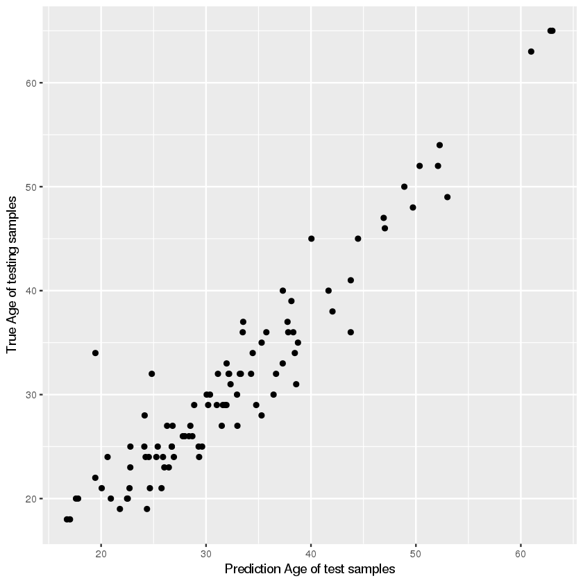

```r
# Plot test correlation plot
qplot(pred, test_age, xlab = "Prediction Age of test samples", ylab = "True Age of testing samples")
```

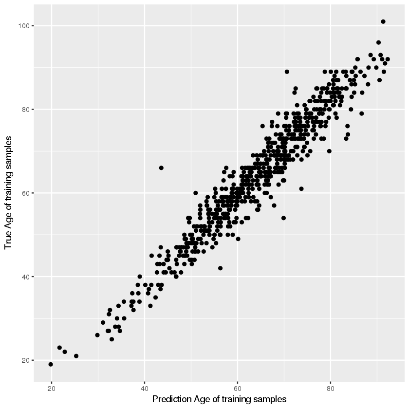

```r
# Plot training correlation plot
qplot(pred_train, train_age, xlab = "Prediction Age of training samples", ylab = "True Age of training samples")
```

```r
test_accelarate <- pred - test_age
train_accelarate <- pred_train - train_age
```

```r
table(test_accelarate>0)
```

```
FALSE  TRUE
   32    63
```

```r
table(train_accelarate > 0)
```

```
FALSE  TRUE
  318   338
```

# BONUS 1

```r
test_sex <- (gse41169.meta[,'characteristics_ch1'])
test_sex <- ifelse(test_sex == 'gender: Male', 'M', 'F')
```

```r
table(test_sex, test_accelarate>0)
```

```
test_sex FALSE TRUE
       F     8   20
       M    24   43
```

```r
chisq.test(table(test_sex, test_accelarate > 0))
```

```
	Pearson's Chi-squared test with Yates' continuity correction

data:  table(test_sex, test_accelarate > 0)
X-squared = 0.19674, df = 1, p-value = 0.6574
```

```r
train_sex <- gse40279.meta[,'characteristics_ch1.3']
train_sex <- ifelse(train_sex == "gender: M", 'M', 'F')
```

```r
table(train_sex, train_accelarate > 0 )
```

```
train_sex FALSE TRUE
        F   174  164
        M   144  174
```

```r
chisq.test(table(train_sex, train_accelarate > 0 ))
```

```
	Pearson's Chi-squared test with Yates' continuity correction

data:  table(train_sex, train_accelarate > 0)
X-squared = 2.2767, df = 1, p-value = 0.1313
```